# Midterm

STAT 471/571/701 Modern Data Mining - Joseph Haymaker

11/07/2017

**Life Expectancy Worldwide**

Life expectancy (denoted as LE) is a measure of how long a person may live. There is significant variation among different countries world wide. The average was 70.5 (68.5 years for males and 73.5 years for females) over the period 2010–2013. Factors related to life expectancy are complex. In this study we focus on factors such as health care, environment, social economic predictors among other controlling factors.

The goal is to identify important factors associated with Life Expectancy and to be able to quantify the relationship. We will also try to predict life expectancy for some countries.

Data: A set of statistics from 2000 – 2013 are available. We are using a piece of it after eliminating some missing values. Original Source: World Bank Group’s Open Data http://data.worldbank.org/

We use the following code to read the data.

- **data.all: all the observations**
- **data2013: information for 2013 only**

| Variable | Description |
| --- | --- |
| Country | Country name |
| LE | Life expectancy |
| Year | Year |
| GDP | GDP per capita |
| Population | Population density |
| Urban.pop | Percentage of urban population |
| Household.consump | Household consumption expenditure in million |
| Unemployment | Unemployment rate |
| Forest.area | Percentage of forest |
| Water | Access to improved water source in percentage |
| Food.prod.index | Food production index |
| Arable.land | Arable land per capita |
| Health.expend | Health expenditure percentage of GDP |
| Immunization | DPT Immunization percentage of children |
| Sanitation.faci | Access to improved sanitation facilities in percentage |
| Immunization.measles | Measles Immunization percentage of children |
| Health.exp.pocket | Percentage of out of pocket health expenditure to total health |
| Fixed.tel | Fixed telephone subscriptions per 100 people |
| Mobile.cel | Mobile cellular subscriptions per 100 people |
| Internet.users | Internet users per 100 people |
| Continent | Continent |

## Question 1 - EDA of data2013

### a) Quick summary

Report the following information:

**i)** Number of variables

```r
dim(data2013)
```

```
## [1] 78 20
```

From the dimensions of the paired down 2013 data we see that there are 78 observations (down from 1779 from the whole original dataset), and 20 variables (down from 21 from the original, taking out `Year` as we saw above).

**ii)** Number of countries

```
##  [1] Australia          Austria            Portugal
##  [4] United States      Czech Republic     Estonia
##  [7] Serbia             Bulgaria           Lithuania
## [10] Latvia             Comoros            France
## [13] Oman               Thailand           Bhutan
## [16] Congo, Dem. Rep.   United Kingdom     Gambia, The
## [19] Chad               Morocco            Benin
## [22] Guinea             Jamaica            Ukraine
## [25] Israel             Germany            Finland
## [28] Slovak Republic    Saudi Arabia       Hungary
## [31] Turkey             Niger              Lesotho
## [34] Belgium            Egypt, Arab Rep.   Spain
## [37] Bolivia            Ecuador            Philippines
## [40] Mali               Mauritius          Mauritania
## [43] Uganda             Togo               Burundi
## [46] Mozambique         Vietnam            Kyrgyz Republic
## [49] Peru               Iran, Islamic Rep. Moldova
## [52] Madagascar         Georgia            Belarus
## [55] Sweden             Norway             Denmark
## [58] Slovenia           Poland             Cuba
## [61] Belize             Tunisia            Lao PDR
## [64] Tanzania           Ghana              Cote d'Ivoire
## [67] El Salvador        Lebanon            Nepal
## [70] Rwanda             Burkina Faso       Guatemala
## [73] Costa Rica         Kazakhstan         Honduras
## [76] Pakistan           Mexico             Chile
## 155 Levels: Afghanistan Albania Algeria Angola Argentina ... Zambia
```

**iii)** Is there any missing value?

```
## [1] 0
```

```
##              Country            Continent                   LE
##                    0                    0                    0
##           Population            Urban.pop                  GDP
##                    0                    0                    0
##    Household.consump         Unemployment          Forest.area
##                    0                    0                    0
##          Arable.land                Water      Food.prod.index
##                    0                    0                    0
##        Health.expend         Immunization      Sanitation.faci
##                    0                    0                    0
## Immunization.measles    Health.exp.pocket            Fixed.tel
##                    0                    0                    0
##           Mobile.cel       Internet.users
##                    0                    0
```

As we can see there are no ‘NA’ values in the overall dataset, or in the individual columns as shown.

**iv)** Is the class/type (e.g. numeric, factor) of each variable appropriate?

```
##       Country           Continent        LE          Population
##  Australia: 1   Africa       :24   Min.   :49.33   Min.   :  3.01
##  Austria  : 1   Asia         :16   1st Qu.:65.17   1st Qu.: 32.09
##  Belarus  : 1   Europe       :24   Median :73.94   Median : 78.52
##  Belgium  : 1   North America: 9   Mean   :70.84   Mean   :120.05
##  Belize   : 1   Oceania      : 1   3rd Qu.:78.05   3rd Qu.:132.25
##  Benin    : 1   South America: 4   Max.   :82.43   Max.   :620.03
##  (Other)  :72
##    Urban.pop          GDP           Household.consump  Unemployment
##  Min.   :11.47   Min.   :   259.4   Min.   : 6.460    Min.   : 0.60
##  1st Qu.:39.23   1st Qu.:  1288.3   1st Qu.: 9.191    1st Qu.: 4.20
##  Median :58.51   Median :  5638.9   Median :10.410    Median : 7.00
##  Mean   :57.12   Mean   : 14064.9   Mean   :10.620    Mean   : 8.05
##  3rd Qu.:74.94   3rd Qu.: 17517.5   3rd Qu.:12.064    3rd Qu.: 9.95
##  Max.   :97.78   Max.   :102832.3   Max.   :16.258    Max.   :31.10
##
##   Forest.area     Arable.land         Water        Food.prod.index
##  Min.   : 0.01   Min.   :0.0100   Min.   : 49.70   Min.   : 83.12
##  1st Qu.:12.94   1st Qu.:0.1025   1st Qu.: 86.03   1st Qu.:103.45
##  Median :30.64   Median :0.2000   Median : 95.85   Median :117.11
##  Mean   :29.34   Mean   :0.2804   Mean   : 89.43   Mean   :117.47
##  3rd Qu.:41.96   3rd Qu.:0.3450   3rd Qu.: 99.58   3rd Qu.:125.86
##  Max.   :79.65   Max.   :2.0000   Max.   :100.00   Max.   :172.83
##
##  Health.expend    Immunization   Sanitation.faci  Immunization.measles
##  Min.   :0.970   Min.   :48.00   Min.   : 10.50   Min.   :59.00
##  1st Qu.:2.518   1st Qu.:85.50   1st Qu.: 49.40   1st Qu.:85.00
##  Median :3.940   Median :94.00   Median : 87.20   Median :94.00
##  Mean   :4.324   Mean   :89.78   Mean   : 72.40   Mean   :89.91
##  3rd Qu.:5.960   3rd Qu.:97.75   3rd Qu.: 97.58   3rd Qu.:97.75
##  Max.   :9.070   Max.   :99.00   Max.   :100.00   Max.   :99.00
##
##  Health.exp.pocket   Fixed.tel        Mobile.cel     Internet.users
##  Min.   : 6.41     Min.   : 0.000   Min.   : 17.71   Min.   : 1.30
##  1st Qu.:19.25     1st Qu.: 3.147   1st Qu.: 81.48   1st Qu.:12.70
##  Median :32.24     Median :12.950   Median :107.54   Median :40.67
##  Mean   :32.05     Mean   :17.664   Mean   :103.54   Mean   :42.13
##  3rd Qu.:44.87     3rd Qu.:28.790   3rd Qu.:126.72   3rd Qu.:69.99
##  Max.   :61.91     Max.   :60.790   Max.   :184.69   Max.   :95.05
##
```

I think as is most of the numeric types makes sense for the variables represented. It is clear that `Country` will need to be eliminated since there is only 1 data point for each country. Additionally, we could consider changing some variables to be categorical, namely ones such as `Sanitation.faci` (Access to improved sanitation facilities in percentage) and `Health.exp.pocket` (Percentage of out of pocket health expenditure to total health). They could be categorized as “high” or “low” based on some threshold we establish. For example countries with a percentage of out of pocket health expenditure greater or equal to 4% would be `HIGH`, while all below would be `LOW`, depending on what aspects of the data we wish to highlight.

### b) Take a look at the response variable LE

**i)** **Make a histogram of LE**

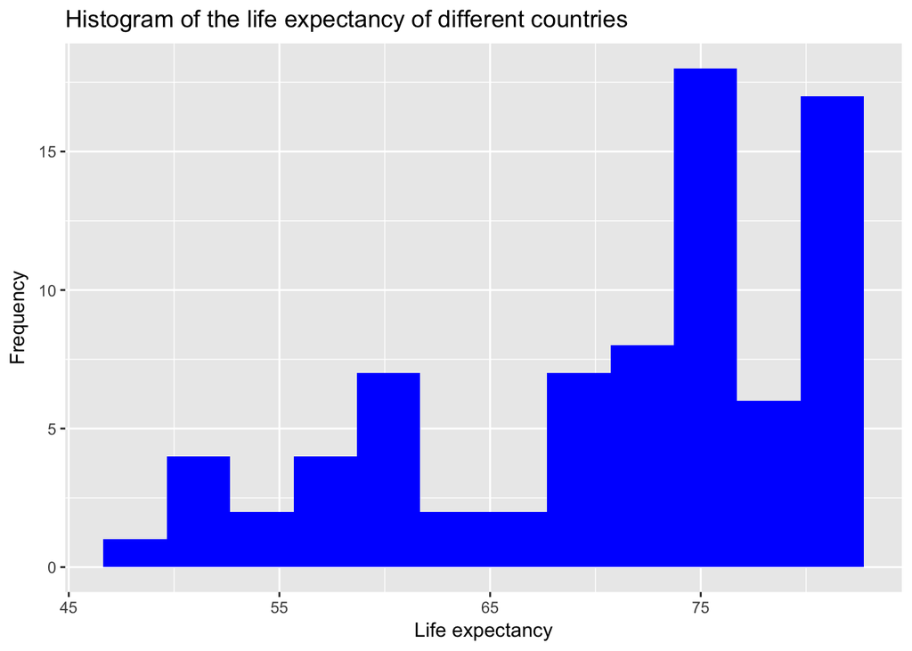

**ii)** **Report summary statistics: min, maximum, mean, sd and median**

```
##    Min. 1st Qu.  Median    Mean 3rd Qu.    Max.
##   49.33   65.16   73.94   70.84   78.05   82.43
```

```
## [1] 9.371366
```

From the summary statistics we can see that the **min** is 49.33 (perhaps higher than some would expect), the **maximum** is 82.43 (perhaps lower than we might expect), **mean** is 70.84 (reasonable), **sd** is 9.371366, **median** is 73.94.

**iii)** **Write a few sentences to summarize the LE worldwide in 2013.** (**No more than three lines**)

### c) A quick exploration for LE vs. Continent

**i)** **Make boxplots of LE by Continent**

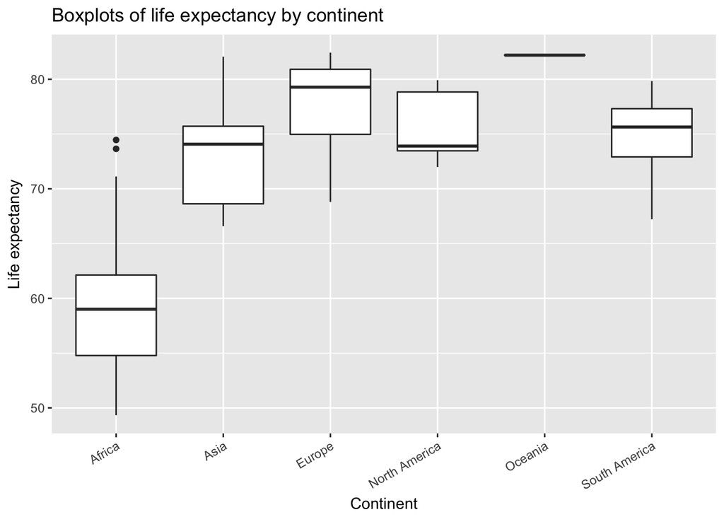

```r
data2013 %>% ggplot(aes(x = Continent, y = LE)) +
  geom_boxplot() +
  theme(axis.text.x = element_text(angle = 30, hjust = 1)) +
  labs(title = "Boxplots of life expectancy by continent", x = "Continent", y = "Life expectancy")
```

**iii)** *Describe briefly the relationship between LE and Continent. Do you see any peculiarities?* (**No more than three lines**)

The most notable discrepancy in the boxplots of `Life expectancy` vs. `Continent` is how much lower the median of Africa is compared to all the other continents. Similarly, Europe and Oceania have very high median values. Other interesting observations are the closeness of the median, 1st, & 3rd quartile in Oceania, and the closeness of the median and 1st quartile in North America. Asia and South America seem to show the most balanced values.

## Question 2 - Explore relationship between LE vs GDP and Continent

### a) LE vs GDP

Let us first examine the relationship between LE and GDP.

**i)** Fit a linear model of LE vs. GDP

- **Make a scatter plot of x=GDP vs. y=LE. together with the regression line overplayed.**

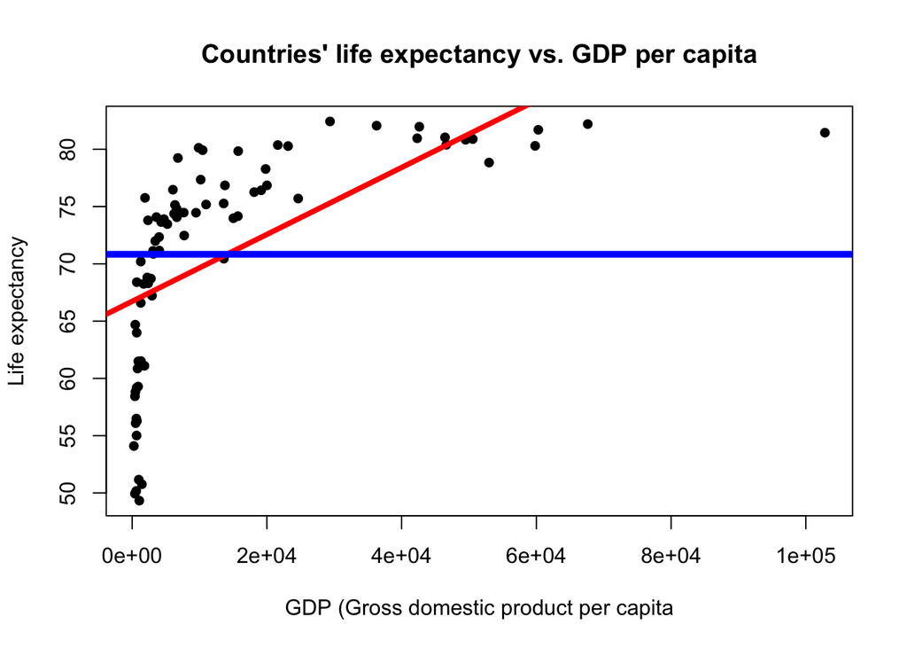

  It’s evident from looking at this plot that a linear model probably isn’t the best to describe the data due to the fact that there is a clump of almost vertidal data points on the lower en of GDP that then levels off, with an extreme outlier at the very right.
- **Report the lm summary statistics**

```
##
## Call:
## lm(formula = LE ~ GDP, data = data2013)
##
## Residuals:
##     Min      1Q  Median      3Q     Max
## -17.707  -4.192   2.329   5.482  10.530
##
## Coefficients:
##              Estimate Std. Error t value Pr(>|t|)
## (Intercept) 6.673e+01  1.031e+00  64.749  < 2e-16 ***
## GDP         2.922e-04  4.255e-05   6.868 1.56e-09 ***
## ---
## Signif. codes:  0 '***' 0.001 '**' 0.01 '*' 0.05 '.' 0.1 ' ' 1
##
## Residual standard error: 7.41 on 76 degrees of freedom
## Multiple R-squared:  0.383,  Adjusted R-squared:  0.3748
## F-statistic: 47.17 on 1 and 76 DF,  p-value: 1.555e-09
```

```
## Anova Table (Type II tests)
##
## Response: LE
##           Sum Sq Df F value    Pr(>F)
## GDP       2589.7  1  47.169 1.555e-09 ***
## Residuals 4172.6 76
## ---
## Signif. codes:  0 '***' 0.001 '**' 0.01 '*' 0.05 '.' 0.1 ' ' 1
```

**ii)** **Fit a linear model of LE vs. log(GDP). Here we use natural log**

- **Make another scatter plot of x=log(GDP) vs. y=LE together with the liner model fit**

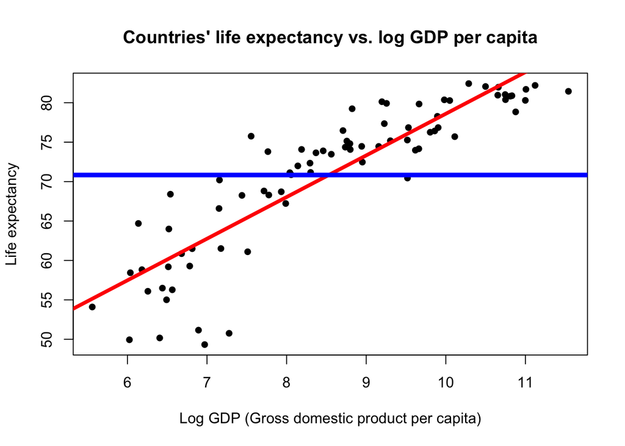

This plot looks much better than just GDP.

- **Report the lm summary statistics**

```r
summary(fit1)
```

```
##
## Call:
## lm(formula = LE ~ logGDP, data = data2013.2)
##
## Residuals:
##      Min       1Q   Median       3Q      Max
## -13.4658  -2.2190   0.2764   2.8015  10.0719
##
## Coefficients:
##             Estimate Std. Error t value Pr(>|t|)
## (Intercept)  25.7744     2.7979   9.212 5.24e-14 ***
## logGDP        5.2837     0.3227  16.371  < 2e-16 ***
## ---
## Signif. codes:  0 '***' 0.001 '**' 0.01 '*' 0.05 '.' 0.1 ' ' 1
##
## Residual standard error: 4.434 on 76 degrees of freedom
## Multiple R-squared:  0.7791, Adjusted R-squared:  0.7762
## F-statistic:   268 on 1 and 76 DF,  p-value: < 2.2e-16
```

```r
Anova(fit1)
```

```
## Anova Table (Type II tests)
##
## Response: LE
##           Sum Sq Df F value    Pr(>F)
## logGDP    5268.4  1  268.02 < 2.2e-16 ***
## Residuals 1493.9 76
## ---
## Signif. codes:  0 '***' 0.001 '**' 0.01 '*' 0.05 '.' 0.1 ' ' 1
```

The `logGDP` variable is still signicant at the .001 level, and in fact has a much higher F value and lower P value.

**iii)** **Which is a better model choice? And why?**

For interpretability the first is preferable, but for fit (which is clearly more important) we should go with `fit1` using `logGDP`, due to the fact that the line fits the data much better, ie better describes the data/minimizes residual error. We can see the adjusted $R^2$ jumped from ~37% to ~78% between the 2 models.

**iv)** **Use your model in **ii)** regardless your answer in **iii)**. Is log(GDP) significant at .01 level in this model? Write down the LS equation and summarize briefly the relationship between GDP and LE.**

$y = 5.2837 * log(GDP) + 25.7744 $

This shows a positive relationship between `log(GDP)` and `LE`.

### b) LE vs GDP and Continent

Now examine the relationship between LE vs GDP and Continent

**i)** **Fit a model of LE vs. Log(GDP) and Continent. Report the summary.**

**ii)** **Is Log(GDP) a significant variable at .01 level after controlling for Continent?**

```
##
## Call:
## lm(formula = LE ~ logGDP + Continent, data = data2013.2)
##
## Residuals:
##      Min       1Q   Median       3Q      Max
## -10.6130  -1.2301   0.0306   2.1698   8.0991
##
## Coefficients:
##                        Estimate Std. Error t value Pr(>|t|)
## (Intercept)              31.890      3.272   9.747 9.94e-15 ***
## logGDP                    4.024      0.463   8.693 8.69e-13 ***
## ContinentAsia             7.019      1.428   4.916 5.50e-06 ***
## ContinentEurope           5.800      1.794   3.232  0.00186 **
## ContinentNorth America    8.253      1.727   4.778 9.27e-06 ***
## ContinentOceania          5.550      4.318   1.285  0.20282
## ContinentSouth America    7.323      2.219   3.300  0.00151 **
## ---
## Signif. codes:  0 '***' 0.001 '**' 0.01 '*' 0.05 '.' 0.1 ' ' 1
##
## Residual standard error: 3.765 on 71 degrees of freedom
## Multiple R-squared:  0.8512, Adjusted R-squared:  0.8386
## F-statistic: 67.67 on 6 and 71 DF,  p-value: < 2.2e-16
```

```
## Anova Table (Type II tests)
##
## Response: LE
##            Sum Sq Df F value    Pr(>F)
## logGDP    1071.18  1 75.5626 8.691e-13 ***
## Continent  487.41  5  6.8764 2.769e-05 ***
## Residuals 1006.50 71
## ---
## Signif. codes:  0 '***' 0.001 '**' 0.01 '*' 0.05 '.' 0.1 ' ' 1
```

`Log(GDP)` is a significant variable at .01 level after controlling for `Continent`, as shown in the Anova test above.

**iii)** **Are the means of LE among all Continents the same after controlling for Log(GDP) at .01 level?** They are not, as seen in the different $\hat \beta$ values shown in the summary.

**iv)** **Which Continent appears to have the lowest LE after controlling for Log(GDP)?**

```
## [1] Oceania       Europe        North America Africa        Asia
## [6] South America
## Levels: Africa Asia Europe North America Oceania South America
```

```
## [1] "Africa"        "Asia"          "Europe"        "North America"
## [5] "Oceania"       "South America"
```

`ContinentAfrica` is the base level, and we can see from the summary above that all other continents correspond with an increase in LE compared to this base level continent. This is in line with the observations we made from the boxplots.

## Question 3 - Model building

We now try to create a parsimonious model to identify important, relevant variables to explain the Life Expectancy. Your professor insists on that GDP should have been taken a log scale! So from now on you may drop GDP from your working data but keep log(GDP) there to avoid any potential problems.

### a) LASSO

Let us start with a LASSO fit using all the sensible variables in the data. Once again make sure that GDP is in log scale. Use **lambda.min**, **set.seed(555)** and **nfold=10** to get the final LASSO features.

```
##  [1] "Country"              "Continent"            "LE"
##  [4] "Population"           "Urban.pop"            "GDP"
##  [7] "Household.consump"    "Unemployment"         "Forest.area"
## [10] "Arable.land"          "Water"                "Food.prod.index"
## [13] "Health.expend"        "Immunization"         "Sanitation.faci"
## [16] "Immunization.measles" "Health.exp.pocket"    "Fixed.tel"
## [19] "Mobile.cel"           "Internet.users"       "logGDP"
```

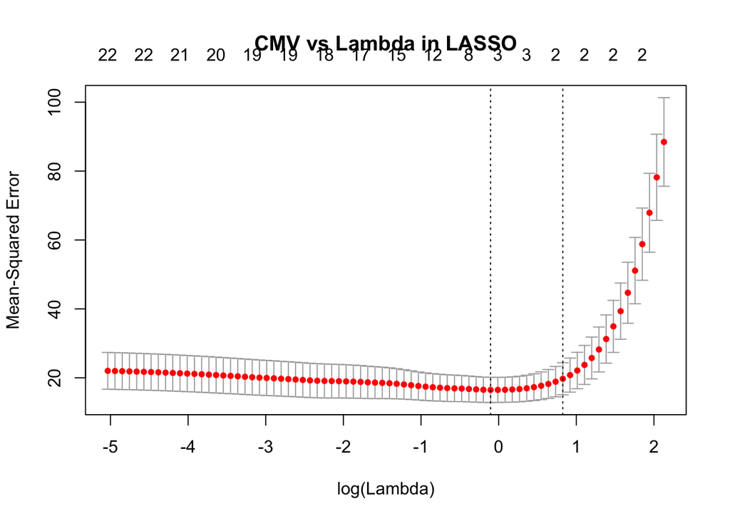

**i)** **Country names should not be a predictor. Explain why not? (**One sentence**)**

Country names should not be a predictor due to the fact that there are only 1 instance of each value in the dataset, and using them would lead to overfitting (no degrees of freedom).

**ii)** **What is the `lambda.min` value? What does it do in this process?** (**one or two sentences**)

```
## [1] 0.9011009
```

The `lambda.min` value is 0.9011009. Of the possible $\lambda$ values we could choose, this one gives us the smalles `cvm` (mean cv error).

**iii)** **What does the random seed control here?**

This allows us to get the same answer each time ; the main point of using the seed is to be able to reproduce a particular sequence of ‘random’ numbers, and thus get the same output each time.

**iv)** What variables are returned using the `lambda.min`? Write down the LASSO prediction equation here.

```
## [1] "(Intercept)"     "Unemployment"    "Water"           "Sanitation.faci"
## [5] "logGDP"
```

```
## [1] "====== LASSO prediction equation ======"
```

```
## LE ~ Unemployment + Water + Sanitation.faci + logGDP
```

### b) Final model

**i)** **Fit a linear model using the features returned from the above LASSO. Perform backward selection until all features are significant at the $\alpha = 0.1$ level to get a final model. Report the summary of your final fit. In particular report the LS equation here.**

```r
fit.lasso <-lm(lm.input, data = data2013.2)
#summary(fit.lasso)
Anova(fit.lasso)
```

```
## Anova Table (Type II tests)
##
## Response: LE
##                 Sum Sq Df F value    Pr(>F)
## Unemployment     81.31  1  7.2999  0.008569 **
## Water             3.49  1  0.3137  0.577146
## Sanitation.faci 350.95  1 31.5068 3.382e-07 ***
## logGDP          316.61  1 28.4239 1.043e-06 ***
## Residuals       813.12 73
## ---
## Signif. codes:  0 '***' 0.001 '**' 0.01 '*' 0.05 '.' 0.1 ' ' 1
```

`Water` not significant, so it can be thrown out.

```r
fit.lasso.1 <- update(fit.lasso, .~. -Water)
summary(fit.lasso.1)
```

```
##
## Call:
## lm(formula = LE ~ Unemployment + Sanitation.faci + logGDP, data = data2013.2)
##
## Residuals:
##     Min      1Q  Median      3Q     Max
## -9.0153 -1.5421  0.0629  2.0530  9.4169
##
## Coefficients:
##                 Estimate Std. Error t value Pr(>|t|)
## (Intercept)     38.77346    2.67755  14.481  < 2e-16 ***
## Unemployment    -0.18994    0.06553  -2.898  0.00493 **
## Sanitation.faci  0.17304    0.02289   7.561 8.72e-11 ***
## logGDP           2.46981    0.45081   5.479 5.64e-07 ***
## ---
## Signif. codes:  0 '***' 0.001 '**' 0.01 '*' 0.05 '.' 0.1 ' ' 1
##
## Residual standard error: 3.322 on 74 degrees of freedom
## Multiple R-squared:  0.8792, Adjusted R-squared:  0.8743
## F-statistic: 179.6 on 3 and 74 DF,  p-value: < 2.2e-16
```

```r
Anova(fit.lasso.1)
```

```
## Anova Table (Type II tests)
##
## Response: LE
##                 Sum Sq Df F value    Pr(>F)
## Unemployment     92.70  1  8.3999  0.004934 **
## Sanitation.faci 630.90  1 57.1703 8.724e-11 ***
## logGDP          331.23  1 30.0156 5.643e-07 ***
## Residuals       816.62 74
## ---
## Signif. codes:  0 '***' 0.001 '**' 0.01 '*' 0.05 '.' 0.1 ' ' 1
```

After removing `Water` all remaining variables – `Unemployment`, `Sanitation.fac`, and `logGDP` – are significant at the .01 level (at least).

**ii)** **Check to see if the model assumptions are reasonably met.**

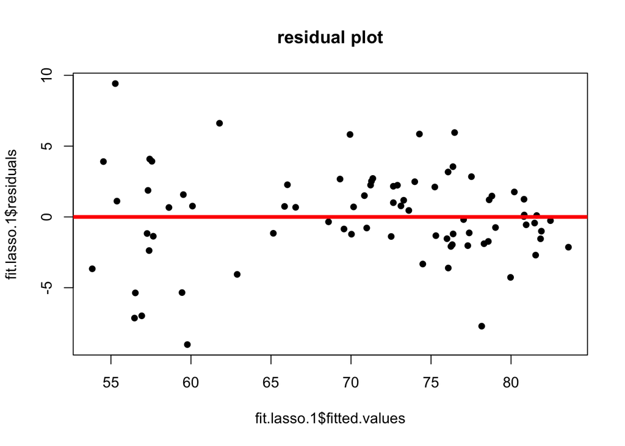

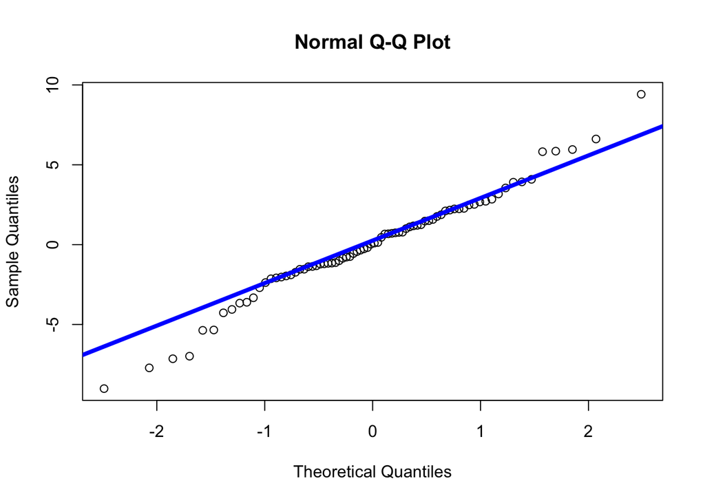

From the residual plot and the qqnorm plot we can see that the model assumptions of linearity, homoscedasticity & normality are more or less fulfilled. With normality (Q-Q plot) the deviations from the straight line are minimal; this indicates normal distribution. And for the other model assumptions, the residual plot shows points that are pretty symmetrically distributed, though some do not cluster towards the middle of the plot. There aren’t any apparent patterns, but the fact that the points on the right side of the plot cluster closer to the smaller y values while those on the left do not does raise some questions.

**iii)** **Write a brief summary of your finding in the final model.**

We find that the variables `Sanitation.fac`, and `logGDP` have a positive effect on a country’s life expectancy, while `Unemployment` shows a negative effect on life expectancy from our model.

**iv)** **Albania is a country that is not in this dataset (year 2013), but some of the statistics in 2013 are given below.**

Albania statistics are:

| Variable | Value |
| --- | --- |
| GDP | 4414 |
| Unemployment | 16.0 |
| Immunization Measles | 96 |
| Fixed.tel | 7.64 |
| Health.exp.pocket | 49.93 |
| Continent | Europe |
| Immunization | 98 |
| Internet.users | 66.36 |

`Water` for 2013 is not available. However, we have `Water` from 2000 to 2008: 96.1, 96.2, 96.1, 96.1, 96.1, 96.0, 96.0, 95.9, 95.8.

`Sanitation.faci` for 2013 is not available either. But we do have its `Sanitation.faci` from 2000 to 2008: 83.4, 84.2, 85.0, 85.8, 86.6, 87.4, 88.1, 88.9, 89.6,

Give an approximate (best possible) 95% Prediction Interval for Albania Life Expectancy in 2013 based on the information above.

```r
Albania <- data2013.2[1,]
Albania$GDP <-  4414
Albania$Sanitation.fac <- 0
Albania$Unemployment <- 16.0
predict(fit.lasso.1, Albania, interval = 'prediction', se = FALSE)
```

```
##        fit      lwr      upr
## 1 80.50675 73.62168 87.39183
```

## Declaration

*JMH*

By submitting this document you certify that you have complied with the University of Pennsylvania’s Code of Academic Integrity, to the best of your knowledge. You further certify that you have taken this exam under its sanctioned conditions, i.e. solely within the set exam room and within the time allotted.